# (Prosper Loan Data Exploration)

## by (Ahmed ElSotohy)

## Investigation Overview

> In this investigation I wanted to investigate what features could affect BorrowerAPR.

## Dataset Overview

> This data set contains 113,937 loans with 81 variables on each loan, including loan amount, borrower rate (or interest rate), current loan status, borrower income, and many others. This data [dictionary](https://www.google.com/url?q=https://docs.google.com/spreadsheet/ccc?key%3D0AllIqIyvWZdadDd5NTlqZ1pBMHlsUjdrOTZHaVBuSlE%26usp%3Dsharing&sa=D&ust=1554484977407000) explains the variables in the data set

## (Distribution of BorrowerAPR)

> BorrowerAPR's distiribution looks multimodal with small, medium, and large peaks. The highest peak is between 0.35, and 0.36 APR.

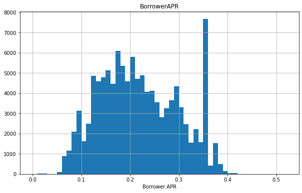

## (Distiribution of Monthly Income)

> I've plotted monthly income on a log scale due to it having a long tail. It looks right skewed, with most borrower's earning less than 30k a month, and only 3% earning more than 30k. However, we have a few borrowers that earns a lot more than 100k a month, and are only taking loans around 5k. We'll consider them as outliers and drop the 3% earning more than 30k a month to better interpret our data.

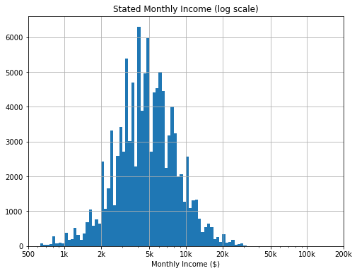

## (Loan Amount by BorrowerAPR and ProsperRating)

> We can observe that BorrowerAPR decreases with better ProsperRating, and also those with better ProsperRating borrows more money. The opposite can be clearly observed for for borrowers with low ProsperRating as they tend to have a high BorrowerAPR, and are borrowing less money.

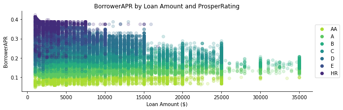

## (BorrowerAPR by Rating and Term)

> We can see that Borrower APR decreases with higher Terms, however that's only from ProsperRating HR till C, as from B till AA, the longer the Term, the higher the BorrowerAPR.

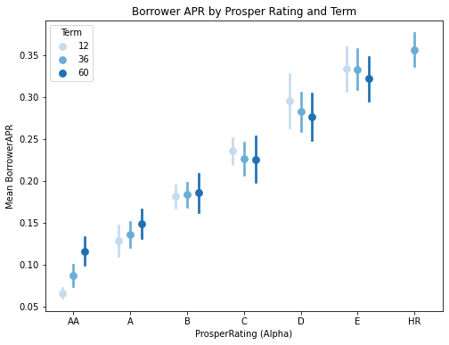

## (Rating & Monthly Income by Loan Amount & Term)

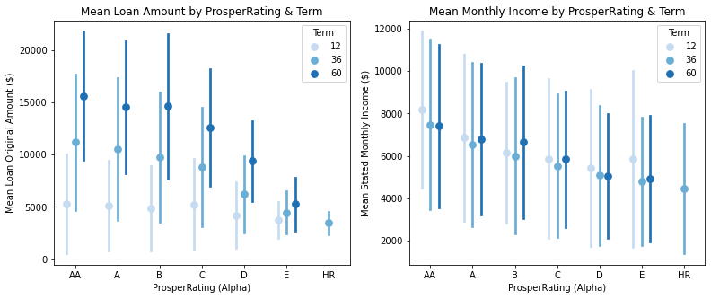